# Milestone Capstone Week 2

Elkin Andres Villa Sanchez

27 septiembre 2020

## Objective

The goal of this project is just to display that you’ve gotten used to working with the data and that you are on track to create your prediction algorithm. Please submit a report on R Pubs (http://rpubs.com/) that explains your exploratory analysis and your goals for the eventual app and algorithm. This document should be concise and explain only the major features of the data you have identified and briefly summarize your plans for creating the prediction algorithm and Shiny app in a way that would be understandable to a non-data scientist manager. You should make use of tables and plots to illustrate important summaries of the data set. The motivation for this project is to:

1. Demonstrate that you’ve downloaded the data and have successfully loaded it in.
2. Create a basic report of summary statistics about the data sets.
3. Report any interesting findings that you amassed so far.
4. Get feedback on your plans for creating a prediction algorithm and Shiny app.

Review criteria

1. Does the link lead to an HTML page describing the exploratory analysis of the training data set?
2. Has the data scientist done basic summaries of the three files? Word counts, line counts and basic data tables?
3. Has the data scientist made basic plots, such as histograms to illustrate features of the data?
4. Was the report written in a brief, concise style, in a way that a non-data scientist manager could appreciate?

## Summary

In order to make an application that can predict the next word a user might be typing, I used data provided by Coursera containing English blog-, twitter- and news-feeds. The first exploratory analysis shows that blogs have to most words per line, and tweets the least. As tweets are limited to 140 characters, this is no surpise.

A further analysis on 1-, 2- and 3-word combinations will give the most frequent word(combination)s.

## Data Retrieval

Both the news and the twitter file gave an error, prohibiting the complete file to be read. I manually searched for this character in NotePad++ and removed it. These are the …HH.txt-files.

```r
blogs <- readLines("data/final/en_US/en_US.blogs.txt", encoding = "UTF-8", skipNul = TRUE)
news <- readLines("data/final/en_US/en_US.newsHH.txt", encoding = "UTF-8", skipNul = TRUE)
twitter <- readLines("data/final/en_US/en_US.twitterHH.txt", encoding = "UTF-8", skipNul = TRUE)
```

## Load Libraries

```r
library(RWeka)
library(stringi)
library(tm)
library(ggplot2)
library(wordcloud)
```

## Exploratory Analysis - 1

First objective is to get a feel for the number of words, lines and characters we’re dealing with.

```r
WpL=sapply(list(blogs,news,twitter),function(x) summary(stri_count_words(x))[c('Min.','Mean','Max.')])
rownames(WpL)=c('WpL_Min','WpL_Mean','WpL_Max')
stats=data.frame(
  Dataset=c("blogs","news","twitter"),
  t(rbind(
  sapply(list(blogs,news,twitter),stri_stats_general)[c('Lines','Chars'),],
  Words=sapply(list(blogs,news,twitter),stri_stats_latex)['Words',],
  WpL)
))
head(stats)
```

```
##   Dataset   Lines     Chars    Words WpL_Min WpL_Mean WpL_Max
## 1   blogs  899288 206824382 37570839       0    41.75    6726
## 2    news 1010242 203223152 34494541       1    34.41    1796
## 3 twitter 2360148 162096241 30451170       1    12.75      47
```

It’s clear, this can’t be done in Excel.

### Sampling and Cleaning data

As the complete dataset creates files that are too large to handle, a sample size of 0.5% turned out to still be workable (1% gave errors, already).

For now no removal of ‘bad words’ yet.

```r
blogs <- iconv(blogs, "latin1", "ASCII", sub="")
news <- iconv(news, "latin1", "ASCII", sub="")
twitter <- iconv(twitter, "latin1", "ASCII", sub="")

set.seed(2138)
sample_data <- c(sample(blogs, length(blogs) * 0.005),
                 sample(news, length(news) * 0.005),
                 sample(twitter, length(twitter) * 0.005))

corpus <- VCorpus(VectorSource(sample_data))
corpus <- tm_map(corpus, tolower)
corpus <- tm_map(corpus, removePunctuation)
corpus <- tm_map(corpus, removeNumbers)
corpus <- tm_map(corpus, stripWhitespace)
corpus <- tm_map(corpus, PlainTextDocument)
```

No actual visible output, just throughput for the next stage.

## Exploratory Analysis - 2

Preparing the data to make a frequency plot of 1-, 2- and 3-word sequences.

```r
uni_tokenizer <- function(x) NGramTokenizer(x, Weka_control(min = 1, max = 1))
bi_tokenizer <- function(x) NGramTokenizer(x, Weka_control(min = 2, max = 2))
tri_tokenizer <- function(x) NGramTokenizer(x, Weka_control(min = 3, max = 3))

uni_matrix <- TermDocumentMatrix(corpus, control = list(tokenize = uni_tokenizer))
bi_matrix <- TermDocumentMatrix(corpus, control = list(tokenize = bi_tokenizer))
tri_matrix <- TermDocumentMatrix(corpus, control = list(tokenize = tri_tokenizer))

uni_corpus <- findFreqTerms(uni_matrix,lowfreq = 50)
bi_corpus <- findFreqTerms(bi_matrix,lowfreq=50)
tri_corpus <- findFreqTerms(tri_matrix,lowfreq=50)

uni_corpus_freq <- rowSums(as.matrix(uni_matrix[uni_corpus,]))
uni_corpus_freq <- data.frame(word=names(uni_corpus_freq), frequency=uni_corpus_freq)
bi_corpus_freq <- rowSums(as.matrix(bi_matrix[bi_corpus,]))
bi_corpus_freq <- data.frame(word=names(bi_corpus_freq), frequency=bi_corpus_freq)
tri_corpus_freq <- rowSums(as.matrix(tri_matrix[tri_corpus,]))
tri_corpus_freq <- data.frame(word=names(tri_corpus_freq), frequency=tri_corpus_freq)
```

Creating the actual plots.

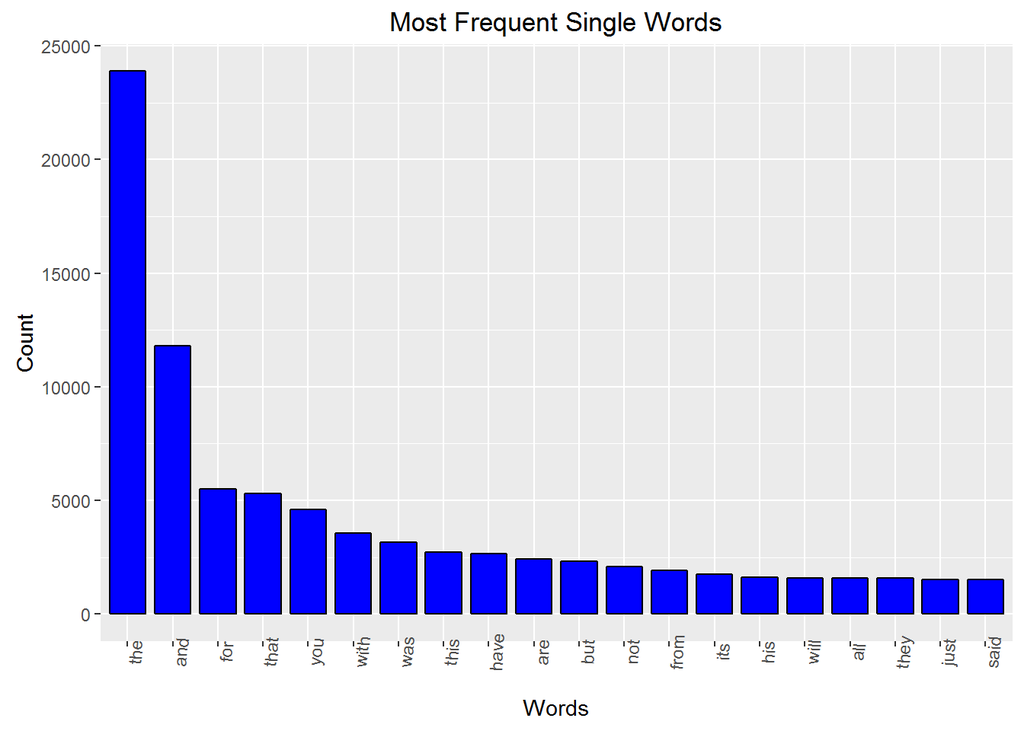

```r
n_gram_plot <- function(num, data, title) {
  df2 <- data[order(-data$frequency),][1:num,]
  df2$word <- factor(df2$word, levels = df2$word[order(df2$frequency, decreasing = TRUE)])
  df2$frequency <- df2$frequency

  ggplot(df2, aes(x = word, y = frequency)) +
    geom_bar(stat = "identity", fill = "blue", colour = "black", width = 0.80) +
    labs(title = title) +
    xlab("Words") +
    ylab("Count") +
    theme(axis.text.x = element_text(angle = 85))
}

n_gram_plot(20, uni_corpus_freq,"Most Frequent Single Words")
```

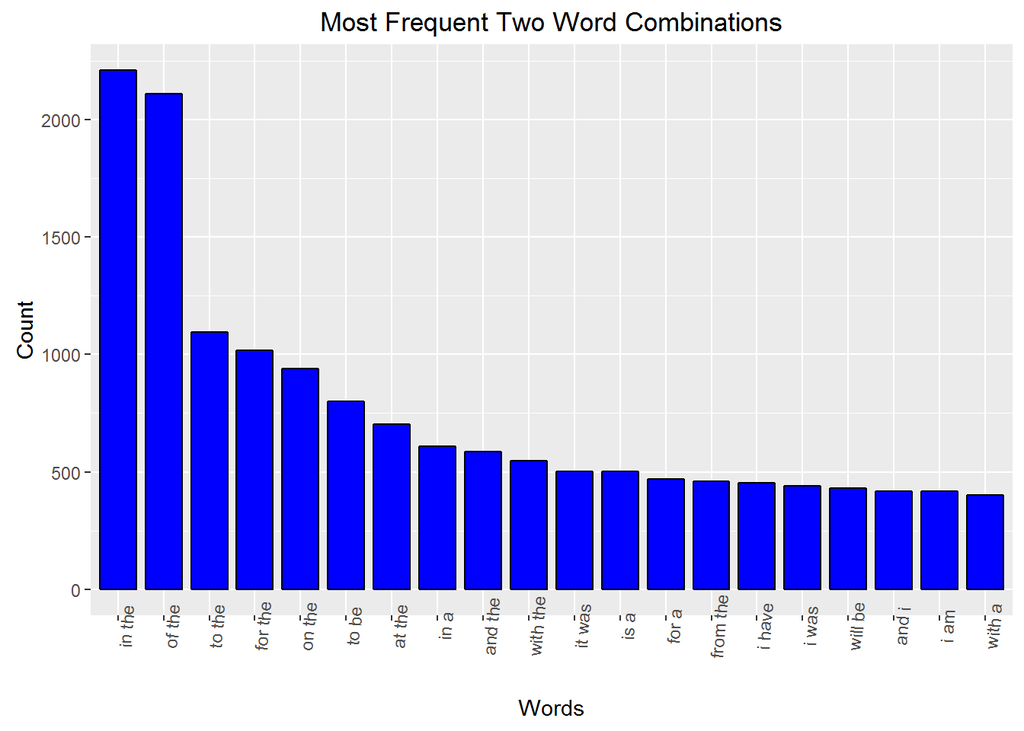

```r
n_gram_plot(20, bi_corpus_freq,"Most Frequent Two Word Combinations")
```

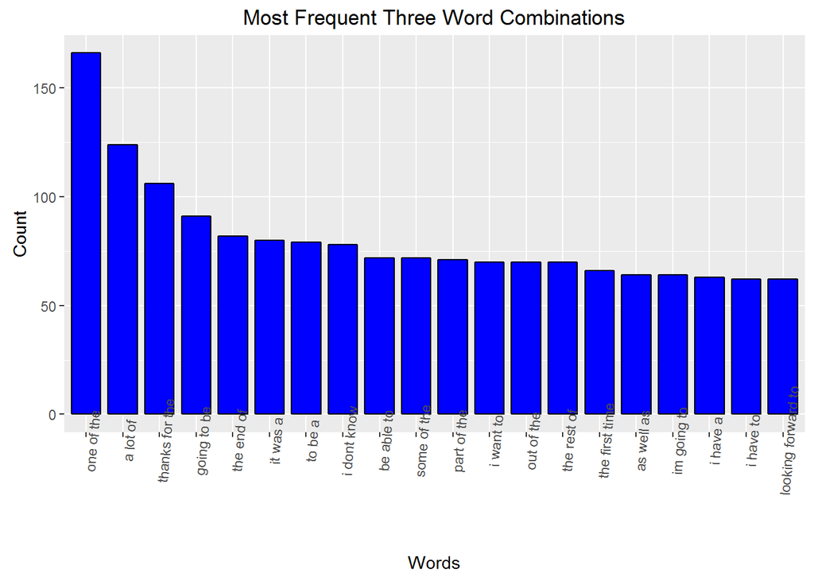

```r
n_gram_plot(20, tri_corpus_freq,"Most Frequent Three Word Combinations")
```

Barplots are very informative, but wordclouds are much more fun to look at!

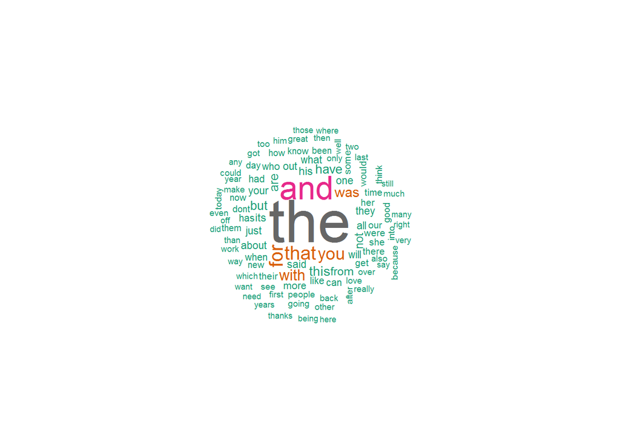

```r
wordcloud(corpus, max.words=100, random.order=FALSE, colors=brewer.pal(8,"Dark2"))
```

## Conclusion and next steps

Even when working with a relative small sample size of 0.5% the resulting most-frequent word(combination)s are recognisable.

The next steps in this course will lead to a slide deck presentation and a shiny app. Should be ready by the end of the year.